# Untitled

## Exploratory Data Analysis (EDA)

### Categorical Variables vs.Death Outcome.

**Proportion of deaths by insurance.**

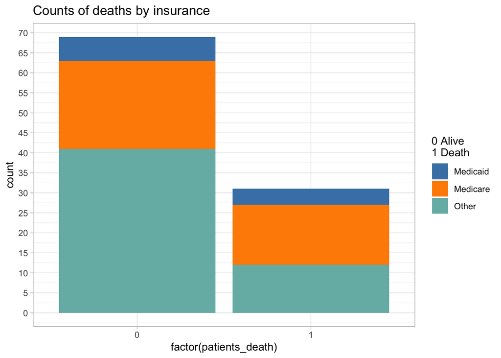

```r
ggplot(patients_mod1, mapping = aes(y = factor(patients_death), fill = insurance)) +
  geom_bar() +
  scale_fill_manual(values = c("Medicaid" = "steelblue",
 "Medicare" = "darkorange",
 "Other" = "#76B7B2"),
name = "0 Alive
1 Death") +
  theme_light() +
  labs(title = "Counts of deaths by insurance") +
  scale_x_continuous(breaks =seq(0,70, by=5))+
  coord_flip()
```

**Proportion of deaths by gender.**

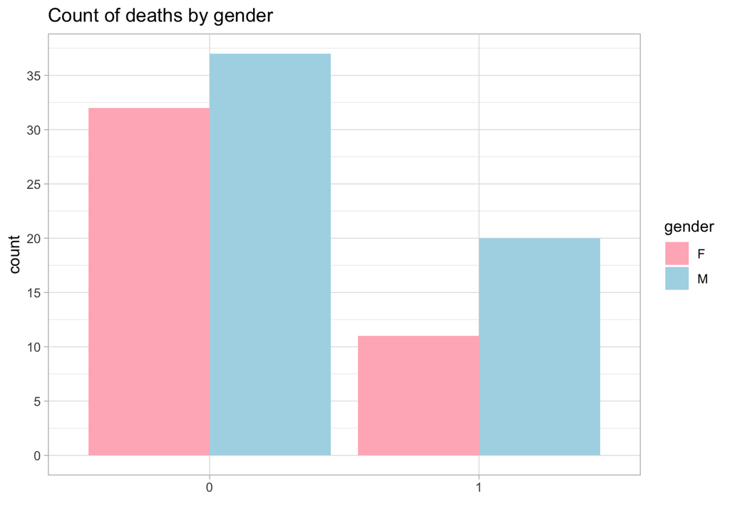

```r
ggplot(patients_mod1, aes(y=factor(patients_death), fill = gender)) +
  geom_bar(position = "dodge") +
  scale_fill_manual(values = c("F" = "lightpink", "M"="lightblue")) +
  labs(title = "Count of deaths by gender",
y = "") +
  scale_x_continuous(breaks = seq(0,50, by= 5)) +
  theme_light() +
  coord_flip()
```

Different names are used to refer to the same variable values. For example: “UNKNOWN, UNABLE TO OBTAIN, OTHER…” I recoded the variable race to group similar categories under a single label.

```r
patients_mod1 <- mutate(patients_mod1, race = case_when(race %in% c("HISPANIC OR LATINO", "HISPANIC/LATINO - CUBAN",  "HISPANIC/LATINO - PUERTO RICAN", "HISPANIC/LATINO - SALVADORAN") ~ "LATINO",
race %in% c("BLACK/AFRICAN AMERICAN","BLACK/CAPE VERDEAN", "BLACK") ~ "BLACK",
race %in% c("WHITE - BRAZILIAN", "WHITE - OTHER EUROPEAN", "WHITE", "PORTUGUESE")~ "WHITE",
race %in% c("UNKNOWN","UNABLE TO OBTAIN","OTHER", "PATIENT DECLINED TO ANSWER") ~ "OTHER", .default= race))
```

**Proportion of deaths by race.**

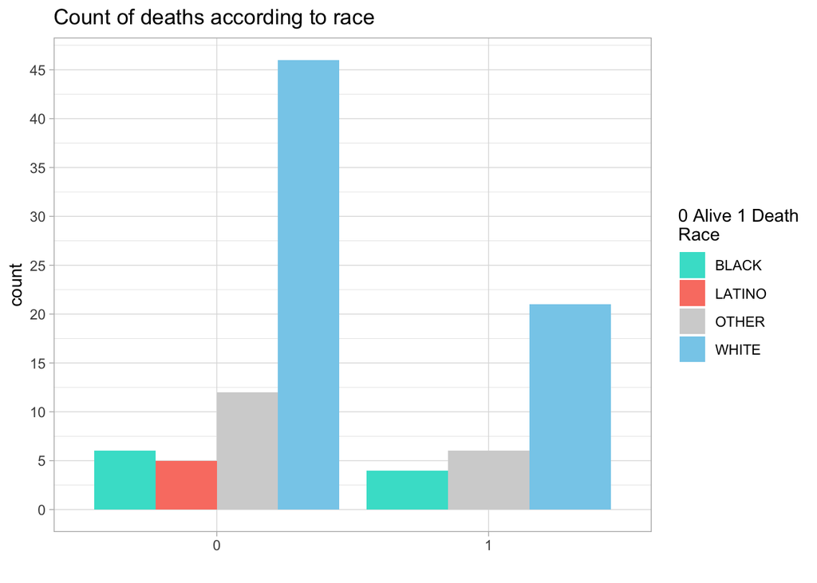

```r
ggplot(patients_mod1,aes(y= factor(patients_death), fill = race)) +
  geom_bar(position = "dodge") +
  scale_fill_manual(values=c("BLACK" = "turquoise", "OTHER" = "lightgray", "WHITE" = "skyblue", "LATINO"="salmon"),
name = "0 Alive 1 Death
Race") +
  theme_light() +
  scale_linetype_binned() +
  scale_x_continuous(breaks = seq(0, 70, by=5)) +
  coord_flip() +
  labs(title = "Count of deaths according to race",
y = "")
```

**Proportion of deaths by admission type.**

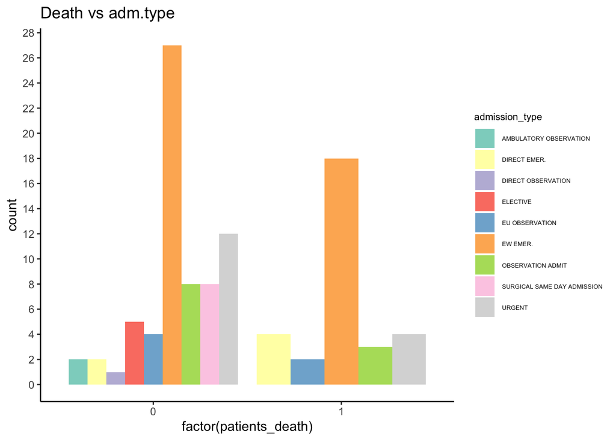

```r
ggplot(patients_mod1, aes(y=factor(patients_death), fill =admission_type)) +
  geom_bar(position = "dodge") +
  coord_flip() +
  theme_classic() +
  theme(legend.text= element_text(size = 5),
legend.title= element_text(size = 8)) +
  scale_x_continuous(breaks = seq(0,30, by=2)) +
  labs(title = "Death vs adm.type") +
   scale_fill_brewer(palette="Set3")
```

### Quantitative Variables vs Death Outcome.

**Average length of stay (hours) by death outcome**

```r
deaths_vs_stay <- group_by(patients_mod1, patients_death) |>
  summarise(media = mean(avg_stay_h),desv = sd(avg_stay_h, na.rm = TRUE),
n = n())
```

```r
deaths_vs_stay <- mutate(deaths_vs_stay, est_error = desv/sqrt(n),
upper_bound_ci = media + qt(0.975, df = n - 1) * est_error,
lower_bound_ci = media - qt(0.975, df = n - 1) * est_error)
```

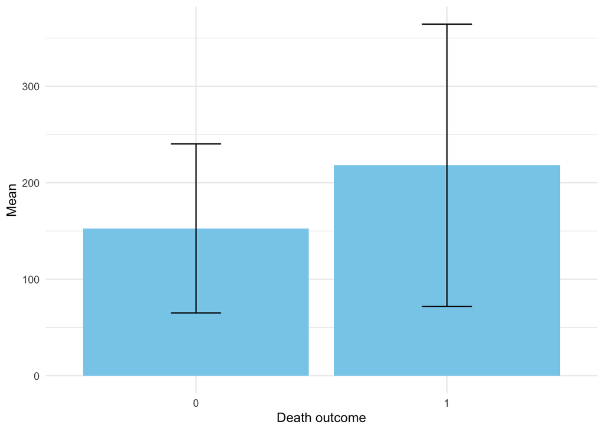

```r
ggplot(deaths_vs_stay, aes(x = factor(patients_death), y=media)) +
  geom_col(fill = "skyblue") +
  geom_errorbar(aes(ymin= media - desv, ymax= media + desv), width = 0.2) +
  xlab("Death outcome") +
  ylab("Mean") +
  theme_minimal()
```

**Number of readmissions within the first 30 days by death outcome**

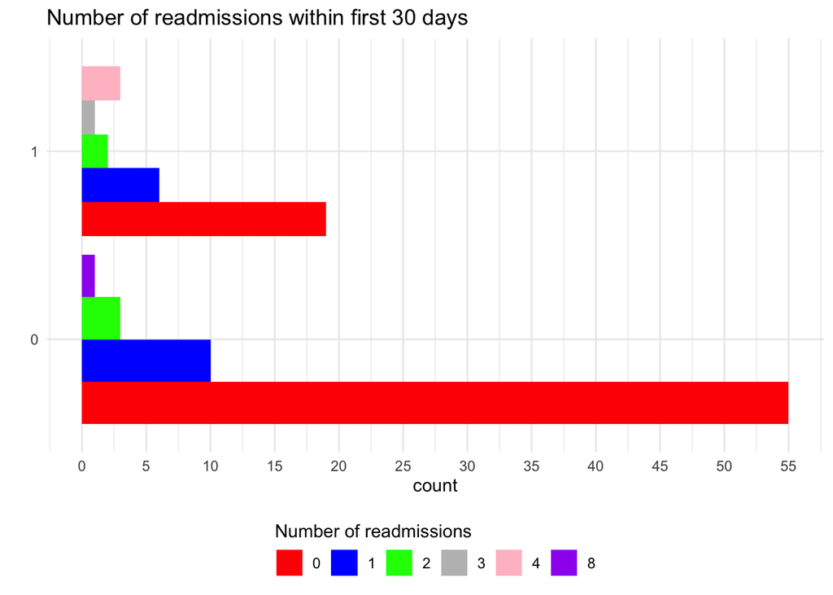

```r
ggplot(patients_mod1, aes(y = factor(patients_death), fill = factor(n_readm_30_days))) +
  geom_bar(position = "dodge") +
  labs(y="", fill = "Number of readmissions") +
  theme_minimal() +
  ggtitle("Number of readmissions within first 30 days") +
  scale_x_continuous(breaks = seq(0,100,by= 5)) +
  theme(legend.text= element_text(size = 9), legend.position="bottom",
legend.title.position = "top") +
  guides(fill=guide_legend(nrow = 1)) +
  scale_fill_manual(values = c("red", "blue", "green", "grey", "pink", "purple"))
```

**Average stay (hours) and number of admissions by death outcome**

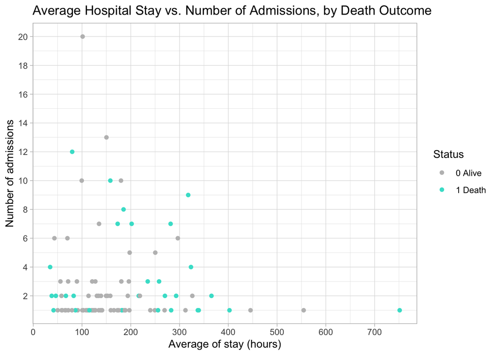

```r
ggplot(patients_mod1, aes(x= avg_stay_h, y =number_admissions, color=factor(patients_death))) +
  geom_point() +
  theme_light() +
  ylab("Number of admissions") +
  xlab("Average of stay (hours)") +
  ggtitle("Average Hospital Stay vs. Number of Admissions, by Death Outcome") +
  scale_x_continuous(breaks = seq(0,800, by= 100)) +
  scale_y_continuous(breaks= seq(0,25, by= 2)) +
  scale_color_manual(name = "Status", values = c("0" = "grey", "1"="turquoise"), labels = c("0" = "0 Alive", "1" = "1 Death"))
```

**Readmissions within 30 days vs number of admissions by death outcome**

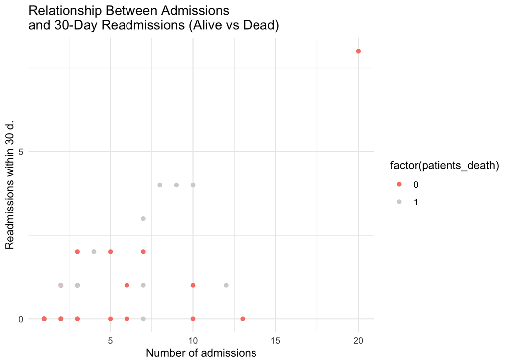

```r
ggplot(patients_mod1, aes(y=n_readm_30_days, x =number_admissions, color = factor(patients_death))) +
  geom_point()+
  ylab("Readmissions within 30 d.") +
  xlab("Number of admissions") +
  theme_minimal() +
  scale_color_manual(values=c("0" = "salmon", "1" = "lightgrey")) +
  scale_y_continuous(breaks = seq(-30, 30, by= 5)) +
  ggtitle("Relationship Between Admissions
and 30-Day Readmissions (Alive vs Dead)")
```

**Hospital stay vs 30-day readmissions by survival**

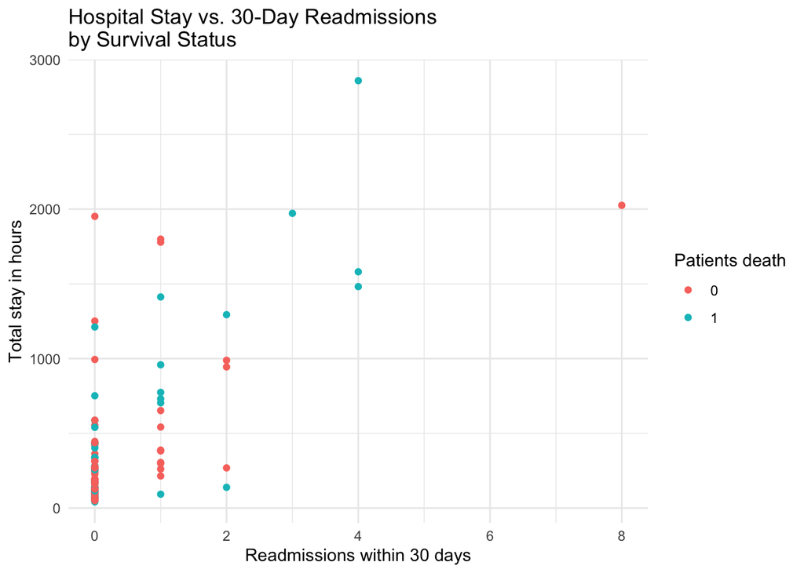

```r
ggplot(patients_mod1, aes(y = total_stay_h, x = n_readm_30_days ,color = factor(patients_death))) +
  geom_point() +
  labs(title = "Hospital Stay vs. 30-Day Readmissions
by Survival Status", x = "Readmissions within 30 days", y = "Total stay in hours", color = "Patients death") +
  theme_minimal()
```

**Number of admissions by admission type and death outcome**

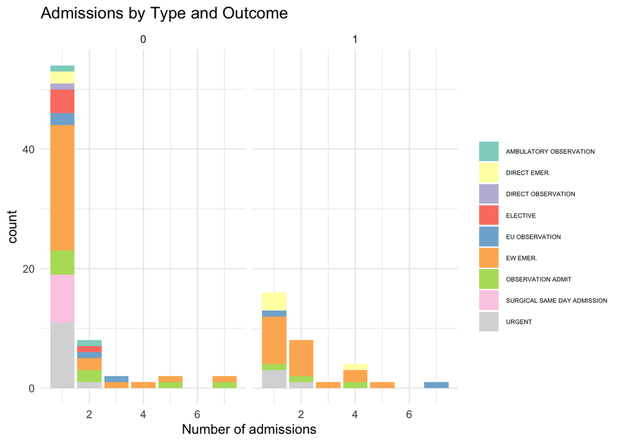

```r
ggplot(patients_mod1, aes(x = admissions_n, fill = admission_type)) +
  geom_bar()+
  facet_wrap(~patients_death) +
  scale_fill_brewer(palette= "Set3") +
  theme_minimal() +
  labs(x = "Number of admissions", title = "Admissions by Type and Outcome", fill = "") +
   theme(legend.text= element_text(size = 5))
```

## **Non-supervised analysis.**

### Clustering quantitative variables.

Patient clustering: selection of relevant variables. Eliminate categorical (character) variables.

```r
patients_mod2 <- select(patients_mod1, -c(subject_id,insurance,gender,anchor_year ,anchor_year_group, dod,
patients_death, race, readm_30_days, admission_type))
```

Visualize the data

```r
summary(patients_mod2)
```

```
##    anchor_age    number_admissions  total_stay_h       avg_stay_h
##  Min.   :21.00   Min.   : 1.00     Min.   :  41.68   Min.   : 34.67
##  1st Qu.:51.75   1st Qu.: 1.00     1st Qu.: 124.33   1st Qu.:102.09
##  Median :63.00   Median : 1.00     Median : 244.72   Median :140.34
##  Mean   :61.75   Mean   : 2.75     Mean   : 453.79   Mean   :172.94
##  3rd Qu.:72.00   3rd Qu.: 3.00     3rd Qu.: 540.56   3rd Qu.:216.75
##  Max.   :91.00   Max.   :20.00     Max.   :2859.72   Max.   :751.38
##   admissions_n  insurance_count n_readm_30_days
##  Min.   :1.00   Min.   : 1.0    Min.   :0.00
##  1st Qu.:1.00   1st Qu.: 1.0    1st Qu.:0.00
##  Median :1.00   Median : 1.0    Median :0.00
##  Mean   :1.67   Mean   : 2.7    Mean   :0.49
##  3rd Qu.:2.00   3rd Qu.: 3.0    3rd Qu.:1.00
##  Max.   :7.00   Max.   :20.0    Max.   :8.00
```

Standardization

```r
patients_scale <- scale(patients_mod2)
summary(patients_scale)
```

```
##    anchor_age      number_admissions   total_stay_h       avg_stay_h
##  Min.   :-2.5201   Min.   :-0.55042   Min.   :-0.7630   Min.   :-1.2278
##  1st Qu.:-0.6184   1st Qu.:-0.55042   1st Qu.:-0.6100   1st Qu.:-0.6291
##  Median : 0.0773   Median :-0.55042   Median :-0.3871   Median :-0.2895
##  Mean   : 0.0000   Mean   : 0.00000   Mean   : 0.0000   Mean   : 0.0000
##  3rd Qu.: 0.6339   3rd Qu.: 0.07863   3rd Qu.: 0.1607   3rd Qu.: 0.3890
##  Max.   : 1.8089   Max.   : 5.42555   Max.   : 4.4544   Max.   : 5.1362
##   admissions_n     insurance_count    n_readm_30_days
##  Min.   :-0.4913   Min.   :-0.53840   Min.   :-0.4228
##  1st Qu.:-0.4913   1st Qu.:-0.53840   1st Qu.:-0.4228
##  Median :-0.4913   Median :-0.53840   Median :-0.4228
##  Mean   : 0.0000   Mean   : 0.00000   Mean   : 0.0000
##  3rd Qu.: 0.2420   3rd Qu.: 0.09501   3rd Qu.: 0.4400
##  Max.   : 3.9085   Max.   : 5.47905   Max.   : 6.4796
```

Set the optimal number of clusters

```r
library(factoextra)
```

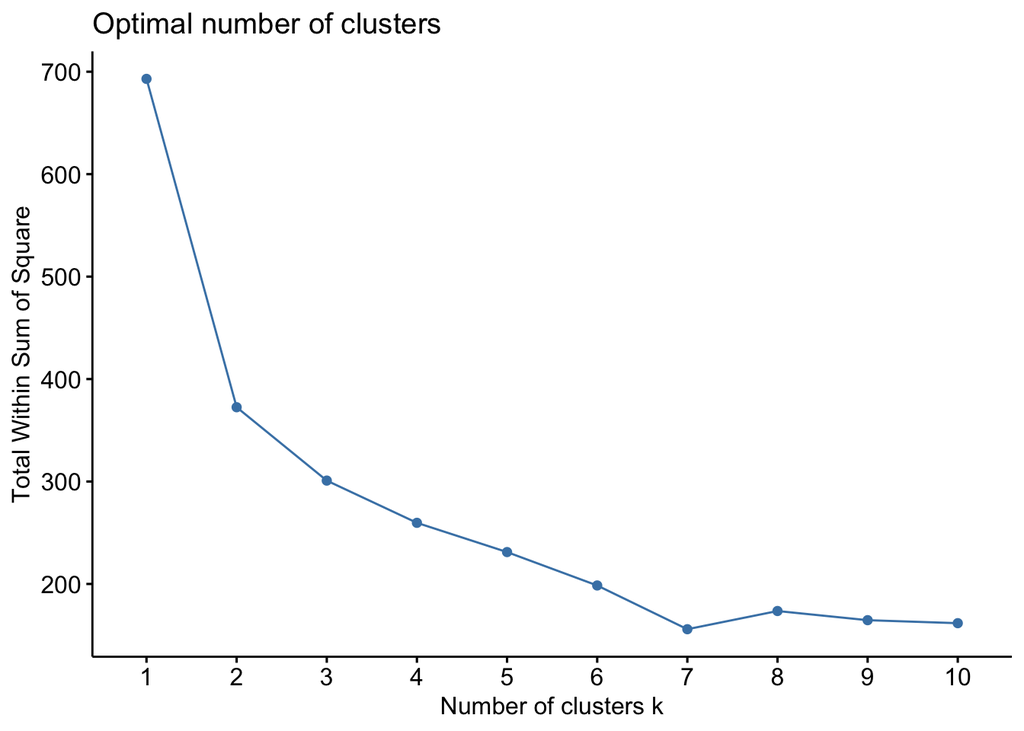

```r
fviz_nbclust(patients_scale, FUNcluster = kmeans, method = "wss")
```

Optimal k = 3

```r
cluster_patients <- kmeans(patients_scale, centers = 3)
vector_cluster <- cluster_patients$cluster
patients_mod1 <- mutate(patients_mod1, clusters_patients = vector_cluster)
```

Patient clusters by number of admissions and average hospital stay

[figure not shown]

```r
ggplot(patients_mod1, aes(y=avg_stay_h, x =number_admissions, color = factor(clusters_patients))) +
  geom_point() +
  xlab("Number of admissions") +
  ylab("Average of stay (hours) ") +
  ggtitle("Patient clustering by admissions
and 30-day readmissions") +
  theme_minimal() +
  scale_x_continuous(breaks= seq(0,40, by=5)) +
  scale_y_continuous(breaks = seq(0,1000, by = 50))
```

Visualization of patient clusters

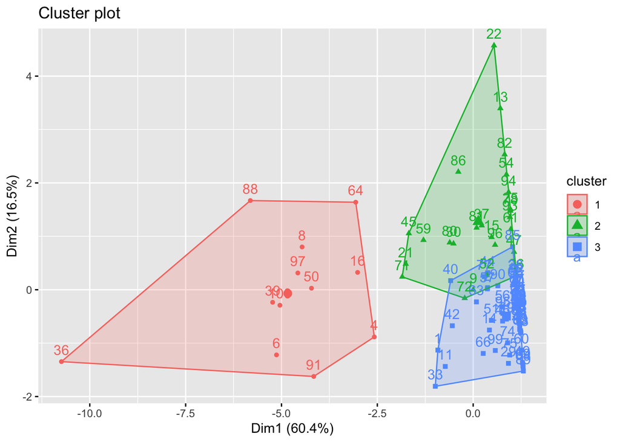

```r
fviz_cluster(cluster_patients,patients_mod2, axes = c(1,2))
```

### Clustering including categorical variables.

```r
library(cluster)
```

I cloned patients_mod1 to patients_mod3 in order to make some changes to the table

```r
patients_mod1 <- mutate(patients_mod1, prop_insurance_count = insurance_count / number_admissions, .after = insurance_count)


patients_mod3 <- patients_mod1
```

In patients_mod3, convert character columns to factors to avoid errors when using daisy, and remove irrelevant categorical variables.

```r
patients_mod3 <- mutate(patients_mod3,subject_id = as.factor(subject_id),
race = as.factor(race),
anchor_year = as.factor(anchor_year),
anchor_year_group = as.factor(anchor_year_group),
gender = as.factor(gender),
dod = as.factor(dod),
admission_type = as.factor(admission_type),
insurance = as.factor(insurance),
patients_death = as.factor(patients_death),
readm_30_days = as.factor(readm_30_days)) |>  select(-c(subject_id, anchor_year,dod, insurance_count, clusters_patients))
```

Gower distance matrix for patients

```r
mat <- daisy(patients_mod3, metric = "gower")
```

Hierarchical clustering of patients (complete linkage)

```r
resultado <- hclust(mat, method = "complete")
```

Dendrogram of patients (complete-linkage clustering)

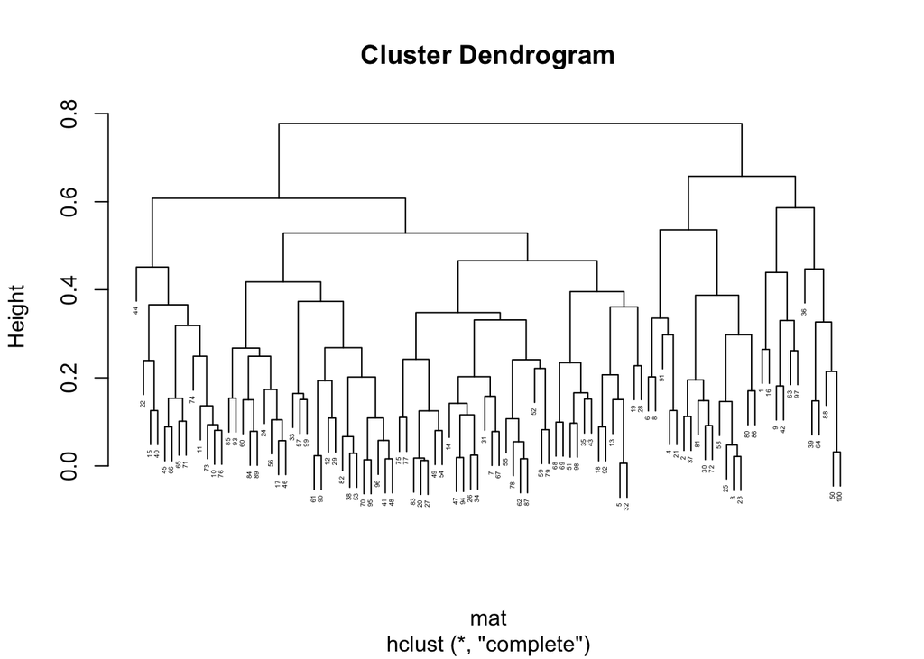

```r
plot(resultado, cex = 0.3)
```

I use factoextra to determine the optimal number of clusters (k = 4).

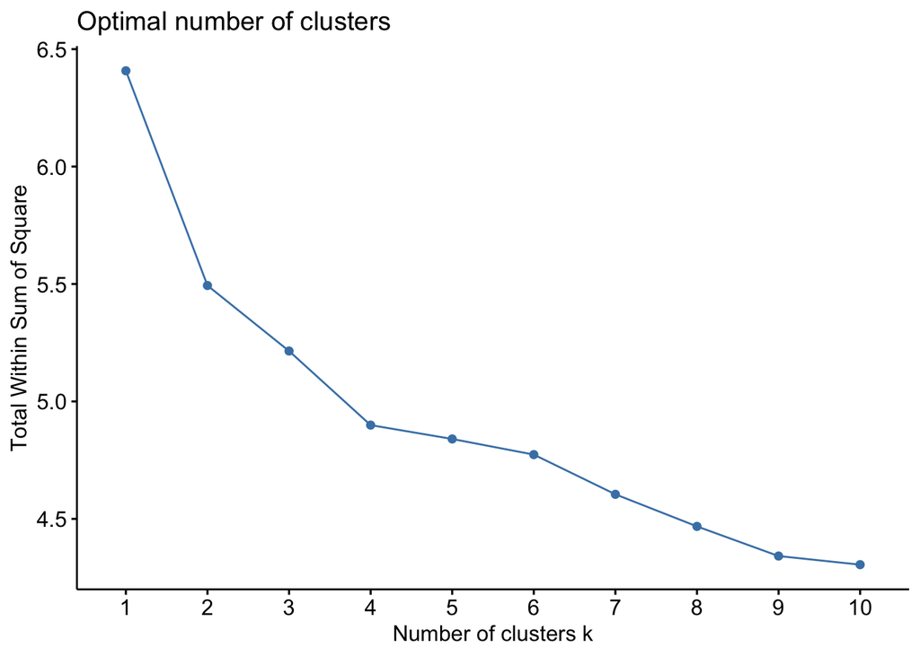

```r
fviz_nbclust(patients_mod3, FUN = hcut, diss = mat, method = "wss")
```

Dendrogram of patients with 4 clusters highlighted.

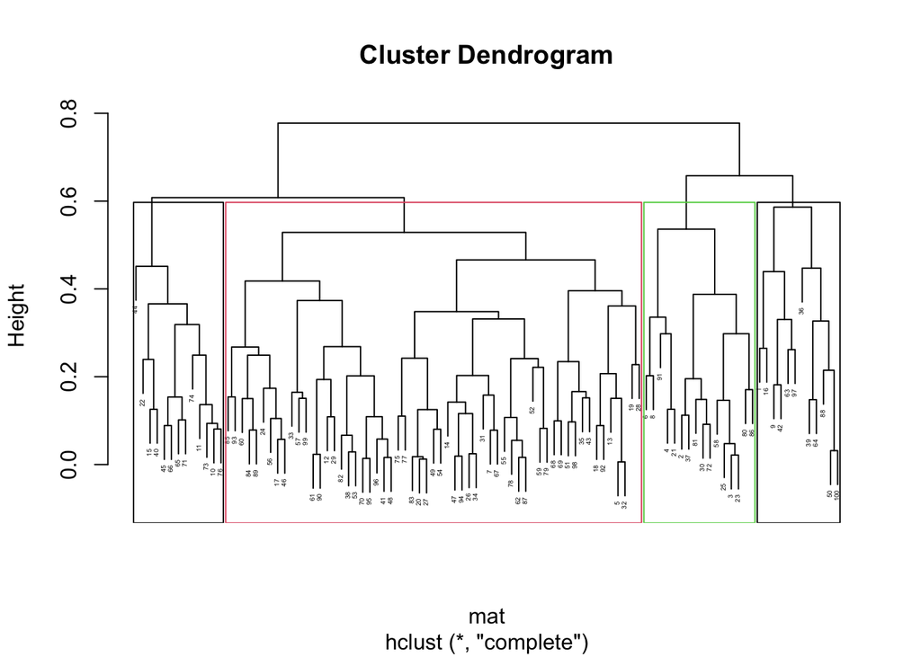

```r
clust <- cutree(resultado, k = 4)
plot (resultado, cex = 0.3)
rect.hclust(resultado, k = 4, border = 1:3)
```

```r
patients_mod1 <- mutate(patients_mod1, clusters_chategorical = clust)
```